# TD8 - Multiplicateur budgétaire

Antoine Mayerowitz

02/12/2017

# Partie 1

À partir de la formulation simple on peut déduire
$$\mathop{ds}=(1-\alpha k)\mathop{dss}$$
Une politique budgétaire restrictive réduit le déficit si $k<\frac{1}{\alpha}$. Si le multiplicateur est élevé, alors l’effet de retour est plus fort (la baisse des dépenses (ou hausse des impôts) se traduit par une baisse d’activité qui va baisser d’autant plus les recettes)

### Exemple: un modèle IS-LM simplissime

> $$Y = C(Y-T) + I + G\\
> \implies Y = cY - cT + I + G\\
> \implies Y = \frac{I - cT + G}{(1-c)}\\
> \implies \frac{\mathop{dY}}{\mathop{dG}} = \frac{1}{1-c}$$
> avec $c$ la propension marginale à consommer des ménages, $Y$ la production (=revenu), $I$ l’investissement, $C$ la consommation, $G$ la dépense publique et $T$ les prélèvements obligatoires. Comment expliquer l’effet multiplicateur ici ? Une baisse des dépenses publiques entraine une baisse du revenu des ménages qui consomment moins, ce qui entraine à nouveau une baisse de la production et donc du revenu et ainsi de suite. Plus les ménages consomment une part importante de leur revenu supplémentaire (càd, plus leur propension marginale à consommer est forte, $c\rightarrow 1$), plus l’effet multiplicateur sera important.

# Partie 2

```r
# On télécharge les données depuis DB.Nomics, un aggrégateur de données développé au Cepremap
api <- "https://api.db.nomics.world/api/v1/sdmx/OECD/data/EO/"

var.list <- c("GAP",        # Output Gap
              "GDPV-ANNPCT",# Real GDP growth
              "GDPVD-CAP",  # Real gross domestic product per capita - USD, constant PPP
              "NLGQA"       # Cyclically adjusted government net lending, as a percentage of potential GDP
)

# Interval d'intérêt
yearMin <- 1995
yearMax <- 2016

# Liste des zones
country.list <- c("USA", "EA16", "GBR", "JPN")

# Je construis l'url pour télécharger mes données
url.countries <- paste0(country.list, collapse = "+")
url.var <- paste0(var.list, collapse = "+")
url <- paste0(api,url.countries,".",url.var,".","A")

# Téléchargement des données
dataSdmx <- readSDMX(url)

# Création de ma base de données
df <- as.data.frame(dataSdmx) %>%
  transmute(countryCode = LOCATION,
            time = TIME_PERIOD,
            var = VARIABLE,
            value = as.numeric(OBS_VALUE)) %>%
  filter(time >= yearMin,
         time <= yearMax) %>%
  spread(var, value) %>%
    group_by(countryCode) %>%
  plyr::rename(c('GDPV-ANNPCT' = 'GDP_GROWTH', 'GDPVD-CAP'='GDP_CAP')) %>%
  mutate(GDPCAPGROWTH = (GDP_CAP-lag(GDP_CAP))/lag(GDP_CAP)*100,
         DNLGQ = (NLGQA-lag(NLGQA)),
         DGAP  = (GAP-lag(GAP))) %>%
  gather(var, value, -time, -countryCode)%>%
  mutate(time = year(as.Date(time, "%Y")))
```

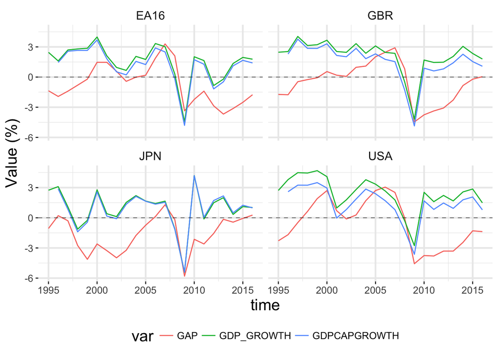

```r
data <- df %>%
  filter(var == "GAP" | var == "GDP_GROWTH" | var == "GDPCAPGROWTH" )

ggplot(data, aes(time, value, colour=var))+
  facet_wrap(~countryCode)+
  geom_line()+
  geom_hline(yintercept = 0, linetype="dashed", color="black", size=0.2)+
  ylab("Value (%)")+
  theme
```

## Question 1

L’éclatement de la bulle internet au début des années 2000 crée un net ralentissement de l’activité en Europe et aux États-Unis, en revanche, l’Angleterre semble peu touchée, quand au Japon, la crise est bien antérieure et l’éclatement de la bulle a relativement peu d’impact.

## Question 2

Qu’est ce que l’output gap ? C’est la différence entre le PIB actuel et le PIB potentiel en pourcentage du PIB potentiel, c’est à dire:
$$gap = \frac{PIB_{actuel}-PIB_{potentiel}}{PIB_{potentiel}}$$
Mais qu’est-ce que le PIB Potentiel me direz-vous ? Il existe quelques définitions, mais la plus largement admise se base sur la [*loi d’Okun*](https://en.wikipedia.org/wiki/Okun%27s_law) et pourrait se résumer ainsi: Le PIB potentiel est le PIB tel qu’il n’y a pas de tension inflationiste (ou le PIB lorsque le chômage est à son taux [structurel](https://en.wikipedia.org/wiki/Natural_rate_of_unemployment))

Le gap donne une information sur la santé de l’économie et permet d’avoir des informations sur la croissance future. Si le gap est négatif, cela indique une possibilité de rattrapage et encourage donc des politiques de stimulations. Le taux de croissance ne nous donne pas d’indication sur la croissance *potentielle* de l’économie. En observant le gap, on a des informations supplémentaires sur la capacité productive de l’économie, ce qui permet de donner des indications sur la politique publique adaptée (relance si potentiel > actuel, réduction du déficit si potentiel < actuel). Son calcul est généralement compliqué mais critique pour l’analyse de la conjoncture. On peut dégager plusieurs méthodes (de la moins sophistiquée à la plus complexe)

- Filtre univarié (Hodrick–Prescott)
- Filtre multivarié (Filtre de Kalman)
- Approche par la “fonction de production” (observation des taux d’utilisation, des capacité de production etc…)
- Modèle économétrique (+ ou - sophistiqué)
- Modèle d’équilibre général (DSGE)

Bien sûr, la complexité de la méthode n’indique en rien la qualité du gap obtenu, et un large débat subsiste encore sur la bonne manière d’estimer celui-ci.

## Question 3

En 2000 on a un simple ralentissement de l’activité. La crise de 2008 est beaucoup plus profonde et on observe une diminution du PIB par habitants. Le phénomène est également généralisé aux 4 zones avec des amplitudes similaires. L’écart de production nous indique également qu’alors que l’éclatement de la bulle internet a eu relativement peu d’effet sur la croissance potentielle, la crise de 2008 a elle des effets de moyen terme avec un écart de production qui ne s’est toujours pas résorbé 8 ans après pour certains pays.

## Question 4

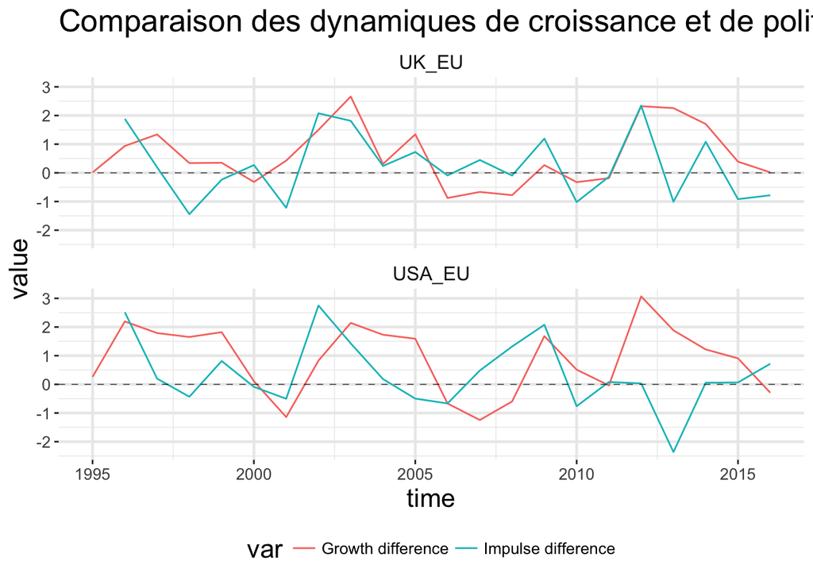

```r
data <- df %>%
  filter(var == "DNLGQ" | var == "GDP_GROWTH") %>%
  spread(countryCode,value) %>%
  filter(!is.na(EA16)) %>%
  mutate(USA_EU = USA-EA16,
         #JPN_EU = JPN-EA16,
         UK_EU  = GBR-EA16) %>%
  select(-USA,-JPN,-GBR,-EA16) %>%
  gather(countryCode, value, -time, -var)%>%
  mutate(value = ifelse(var=="DNLGQ",-value,value),
         var = ifelse(var=="DNLGQ","Impulse difference","Growth difference"))


ggplot(data, aes(time, value, colour=var))+
  facet_wrap(~countryCode, nrow=3)+
  geom_line()+
  geom_hline(yintercept = 0, linetype="dashed", color="black", size=0.2)+
  ggtitle("Comparaison des dynamiques de croissance et de politique budgétaire")+
  theme
```

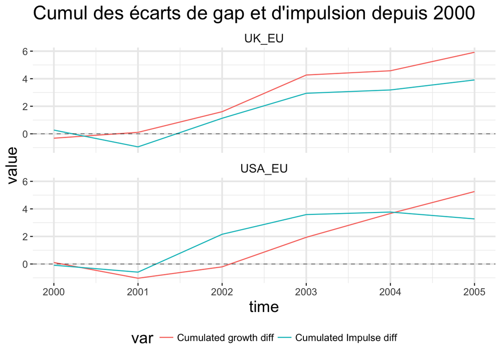

```r
data <- data %>%
  group_by() %>%
  mutate(var = ifelse(var=="Impulse difference","Cumulated Impulse diff","Cumulated growth diff")) %>%
  group_by(var, countryCode) %>%
  filter(time >= 2000,
         time <= 2005)%>%
  mutate(value = cumsum(value))

ggplot(data, aes(time, value, colour=var))+
  facet_wrap(~countryCode, nrow=3)+
  geom_line()+
  geom_hline(yintercept = 0, linetype="dashed", color="black", size=0.2)+
  ggtitle("Cumul des écarts de gap et d'impulsion depuis 2000")+
  theme
```

# Partie 3

## Question 1

Commence fin 2008 avec une importante chutte de l’activité. Lorsqu’on obeserve le gap en 2007 on peut voir que celui-ci est très positif, ce qui suggère une surchauffe de l’activité. Avec la crise, le gap devient très nettement négatif et ne se résorbe que presque 10 ans après. Dans le cas de la zone euro on observe que la reprise amorçée en 2010 s’arrête brutalement suite à la crise des dettes souveraines.

## Question 2

```r
df %>% filter(countryCode == "EA16",
              time >= 2007) %>%
  spread(var, value) %>%
  group_by() %>%
  transmute(time = time,
            Output_gap = round(GAP,2),
            PIB_par_tete = round(GDP_CAP),
            Impulsion = round(-DNLGQ,2))%>%
  gather(var, value, -time) %>%
  spread(time,value)
```

|  | var | 2007 | 2008 | 2009 | 2010 | 2011 | 2012 | 2013 | 2014 | 2015 | 2016 |
| --- | --- | --- | --- | --- | --- | --- | --- | --- | --- | --- | --- |
| 1 | Impulsion | -0.12 | 0.90 | 1.10 | 0.51 | -1.54 | -1.47 | -1.07 | -0.15 | -0.09 | -0.08 |
| 2 | Output_gap | 3.30 | 2.11 | -3.36 | -2.22 | -1.40 | -2.86 | -3.68 | -3.13 | -2.52 | -1.76 |
| 3 | PIB_par_tete | 37408.00 | 37341.00 | 35547.00 | 36161.00 | 36623.00 | 36192.00 | 36020.00 | 36423.00 | 37029.00 | 37549.00 |

La croissance de la zone euro devient négative dès 2009. L’écart de production se creuse entre 2008 et 2009 de 5,5 points de PIB. C’est considérable. En 2008, par rapport à 2007, l’écart de production se réduit de 1,2 point. Bien que la croissance ne soit pas négative, c’est un sérieux ralentissement. En fait, la récession commence au milieu de l’année 2008 et donne son plein effet en 2009.

Au niveau de la politique budgétaire, l’impulsion est positive de 0.9 point en 2008, de 1,1 point en 2009 et encore de 0.5 point en 2010. Au total, cela fait 2.5 points. L’impulsion positive n’est pas à la hauteur de la perte de production (la variation de l’écart de production) principalement parce que l’information en temps réel (au moment où se produit la récession) minore initialement l’ampleur de la récession. La politique qui est décidée alors se fait sur une évaluation biaisée qui minore donc l’ampleur de la crise. Néanmoins, le précepte keynésien est bien appliqué avec une impulsion très positive pour soutenir l’économie. A partir de 2011, la politique budgétaire de la zone euro s’inverse radicalement. La mécanique de ce changement de politique sera vu plus tard dans un prochain TD, mais il est important de noter ici que la politique budgétaire devient fortement restrictive. -1,5 points d’impulsion en 2011 et à nouveau -1.5 points en 2012, soit plus que ce qui avait été utilisé comme levier de stimulation entre 2008 et 2010. L’ordre de grandeur est assez considérable. A l’échelle de la France, pour faire une impulsion de -3 points, il faut soit couper la moitié du budget de l’éducation ou encore presque doubler l’impôt sur le revenu. En effet l’impôt sur le revenu sur les personnes physiques (hors CSG) a rapporté de l’ordre de 70 milliards en 2016. Pour un PIB de l’ordre de 2000 milliards d’euros, cela représente autour de 3.5 points de PIB. L’effort de consolidation, à l’échelle de la zone euro, se poursuit en 2013, puis s’atténue en 2014 et au-delà. En retenant un multiplicateur autour de 1, on imagine que cela a pu avoir un impact fort sur l’activité et participé à la rechute de l’activité (le creusement de l’écart de production) à partir de 2012. Entre 2011 et 2013 l’écart de production se creuse en zone euro de 2,3 points.

## Question 3

```r
var.list <- c("GAP",        # Output Gap
              "GDPVD-CAP",  # Real gross domestic product per capita - USD, constant PPP
              "NLGQA"       # Cyclically adjusted government net lending, as a percentage of potential GDP
)

# Area list
country.list <- c("JPN","USA","GBR","FRA","ITA","GRC","ESP","PRT","FIN","BEL","SVK","AUT","NLD","DEU")

url.countries <- paste0(country.list, collapse = "+")
url.var <- paste0(var.list, collapse = "+")

url <- paste0(api,url.countries,".",url.var,".","A")

# Download data
dataSdmx <- readSDMX(url)

df <- as.data.frame(dataSdmx) %>%
  transmute(countryCode = LOCATION,
            time = TIME_PERIOD,
            var = VARIABLE,
            value = as.numeric(OBS_VALUE)) %>%
  filter(time >= yearMin,
         time <= yearMax) %>%
  spread(var, value) %>%
    group_by(countryCode) %>%
  plyr::rename(c('GDPVD-CAP'='GDP_CAP')) %>%
  mutate(DNLGQ = (NLGQA-lag(NLGQA))) %>%
  gather(var, value, -time, -countryCode)

data <- df %>%
  filter(var == "GAP" | var == "DNLGQ" | var == "GDP_CAP",
         !is.na(value))
```

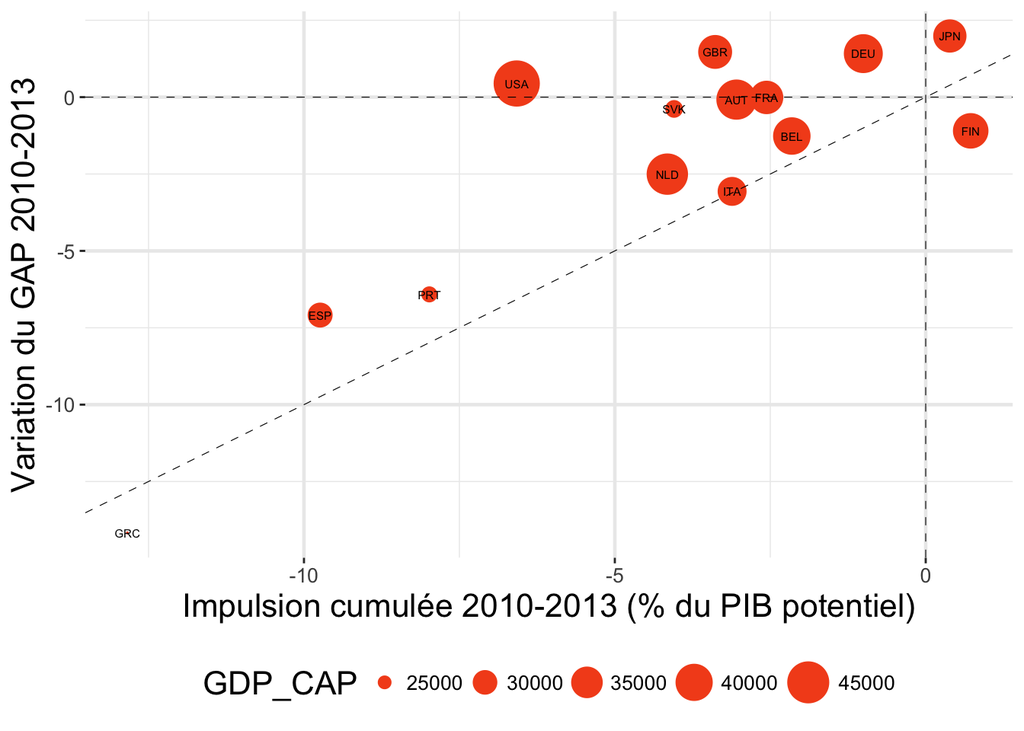

```r
d1 <- data %>%
  filter(time <= 2013,
         time >= 2010) %>%
  spread(var, value) %>%
  mutate(CumImpulse = cumsum(-DNLGQ),
         DGAP = last(GAP)-first(GAP)) %>%
  filter(time == max(time),
         !is.na(CumImpulse))

ggplot(d1, aes(CumImpulse, DGAP, label=countryCode, tooltip = countryCode))+
  geom_point(aes(size = GDP_CAP),color=red)+
  geom_text(hjust = 0.5, size = 2) +
  geom_hline(yintercept = 0, linetype="dashed", color="black", size=0.2)+
  geom_vline(xintercept = 0, linetype="dashed", color="black", size=0.2)+
  scale_size(range = c(0, 10))+
  ylab("Variation du GAP 2010-2013")+
  xlab("Impulsion cumulée 2010-2013 (% du PIB potentiel)")+
  geom_abline(intercept = 0, slope = 1, color="black",
                 linetype="dashed", size=0.2)+
  theme
```

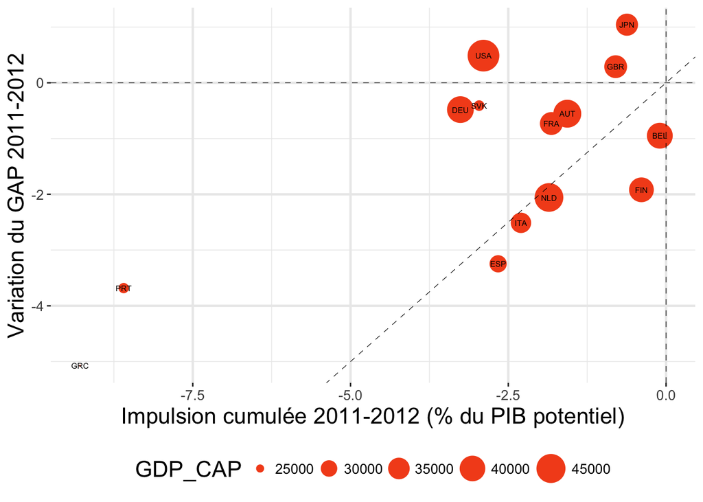

```r
d1 <- data %>%
  filter(time <= 2012,
         time >= 2011) %>%
  spread(var, value) %>%
  mutate(CumImpulse = cumsum(-DNLGQ),
         DGAP = last(GAP)-first(GAP)) %>%
  filter(time == max(time),
         !is.na(CumImpulse))

ggplot(d1, aes(CumImpulse, DGAP, label=countryCode))+
  geom_point(aes(size = GDP_CAP),color=red)+
  geom_text(hjust = 0.5, size = 2) +
  geom_hline(yintercept = 0, linetype="dashed", color="black", size=0.2)+
  geom_vline(xintercept = 0, linetype="dashed", color="black", size=0.2)+
  scale_size(range = c(0, 10))+
  ylab("Variation du GAP 2011-2012")+
  xlab("Impulsion cumulée 2011-2012 (% du PIB potentiel)")+
  geom_abline(intercept = 0, slope = 1, color="black",
                 linetype="dashed", size=0.2)+
  theme
```